# CPBS 7630 Module 5 - Bagging and boosting

April 26, 2016

#### Contents:

- Boosting
- Bagging

This template requires the [`adabag` package](https://www.jstatsoft.org/index.php/jss/article/view/v054i02/adabag_An_R_Package_for_Classification_with_Boosting_and_Bagging.pdf) for boosting and bagging functions, `curatedOvarianData` for a real-life data set, and `rpart.plot` for pretty plotting regression trees. All packages are available on CRAN.

### Boosting

##### Small, toy data set

Here, we’ll use boosting on the `iris` data set to classify examples by the species of iris that they came from. First, we load the data set and make some exploratory plots.

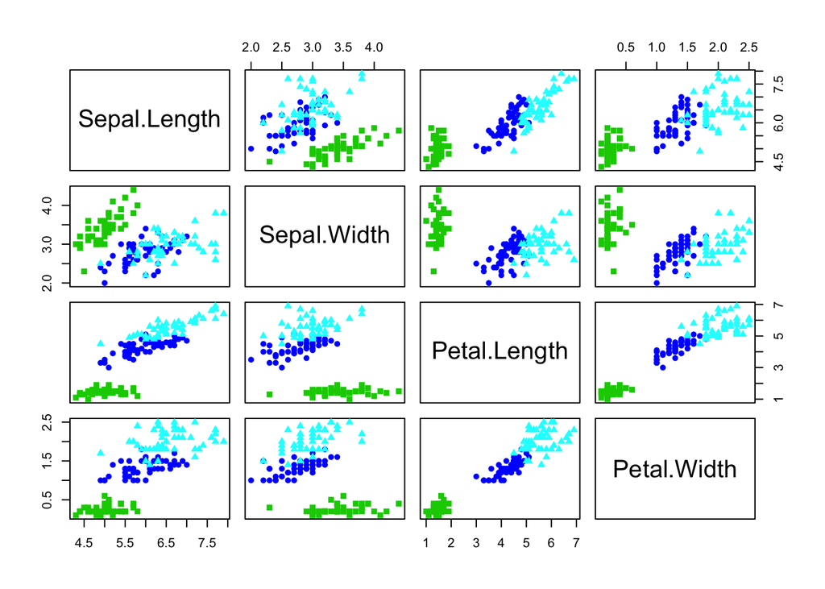

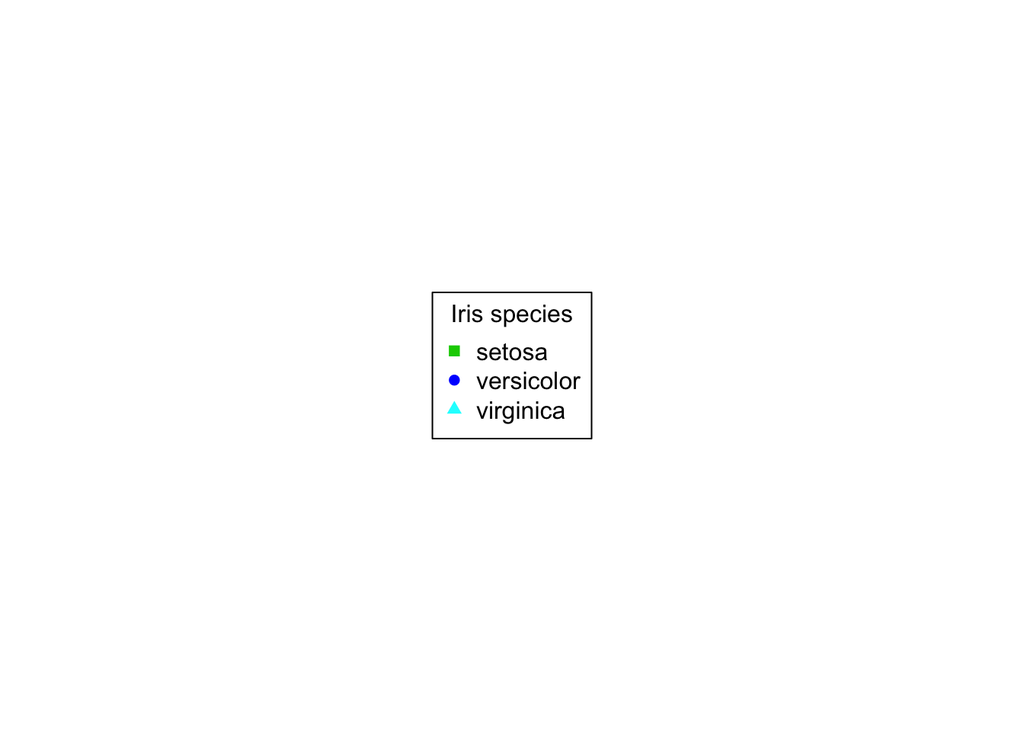

```r
# Load iris data set
data(iris)

# Plot the 4 variables included in the data set
#my.layout = layout(cbind(1,2), widths = c(7,3))
par(mar = c(0,0,0,0))
plot(iris[,-5], col = c(3:5)[iris$Species], pch = c(15:17)[iris$Species])
plot.new()
legend('center', legend = levels(iris$Species), title = 'Iris species',
       col = 3:5, pch = 15:17)
```

```r
# These lines would plot just two of the variables, sepal length and sepal width,
# and label the examples by their index
plot(iris[,1:2], col = c(3:5)[iris$Species], pch = c(15:17)[iris$Species])
text(iris[,1:2], labels=1:150)
```

We can use the `adabag` R package for its `boosting()` and `bagging()` functions. Read the manual pages for each function to understand additional parameters not included in these examples.

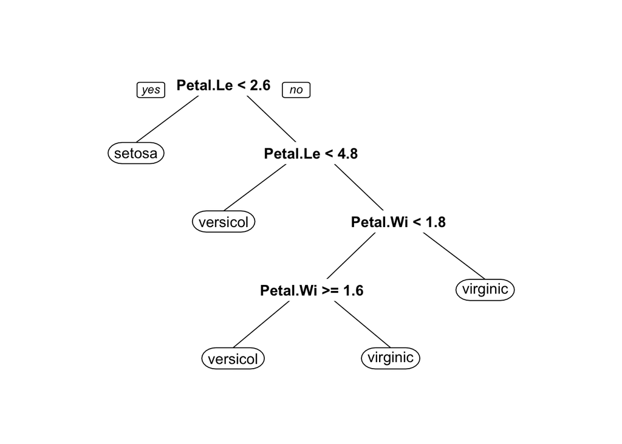

```r
library(adabag)
library(rpart.plot)

# Perform boosting on the iris data
iris.adaboost <- boosting(Species~., data = iris, boos = TRUE, mfinal = 10)

# Pretty plot one of the trees as an example (with rpart.plot package)
prp(iris.adaboost$trees[[5]])
```

The `boosting()` function will iterate over the data as many times as we define in the `mfinal` parameter. Each iteration produces one tree. Explore the `iris.adaboost` data object. What information is contained in this structure?

In theory, boosting should give us better performance at each iteration. Was this true? When did the performance max out? One way to address these questions is by visualizing the number of examples that we incorrectly classified at each iteration.

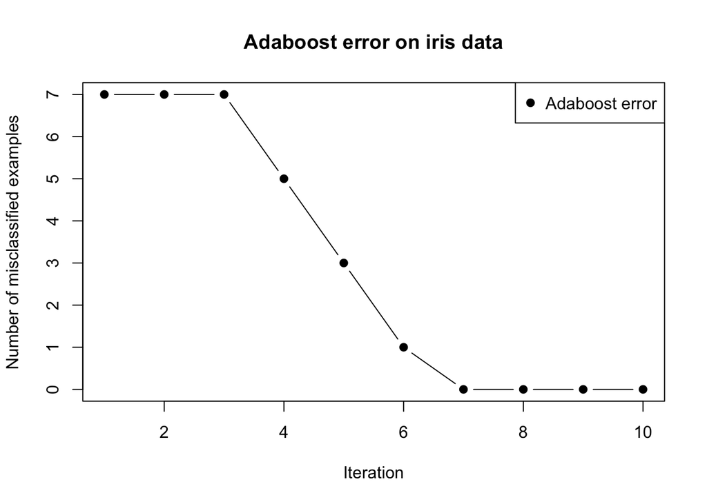

```r
# Plot the number of misclassified examples by iteration
errors = errorevol(iris.adaboost, newdata = iris)$error   # percentage error
plot(errors*nrow(iris),
     main = 'Adaboost error on iris data',
     xlab = 'Iteration', ylab = 'Number of misclassified examples',
     pch = 19, type = 'b')
legend('topright', legend = 'Adaboost error', col = 'black', pch = 19)
```

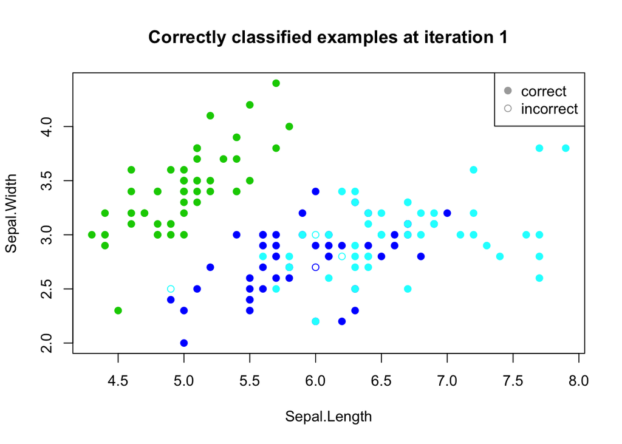

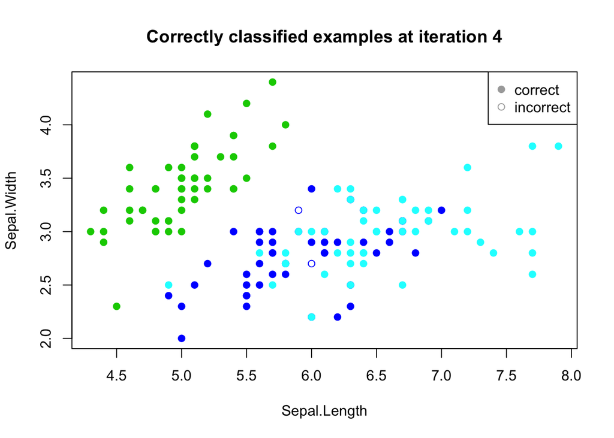

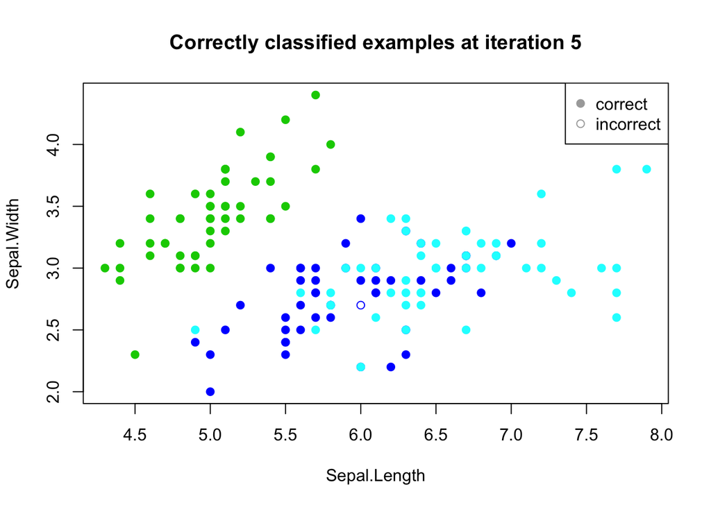

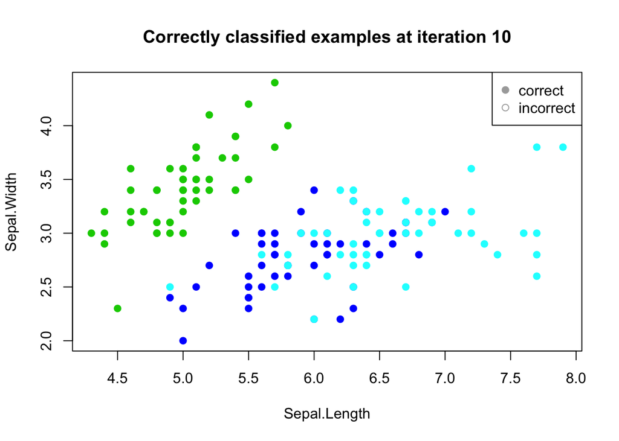

```r
# Compare correct/incorrect class assignments at iteration 1, 4, 5 and 10
true.classes = iris$Species
for (i in c(1,4,5,10)){
     class.assignments = boosting(Species~., data = iris, boos = TRUE, mfinal = i)$class
     correct = class.assignments == true.classes
     plot.title = paste0('Correctly classified examples at iteration ', i)
     plot(iris[,1:2], col = c(3:5)[iris$Species], pch = ifelse(correct, 19,1),
          main = plot.title)
     legend('topright', legend = c('correct', 'incorrect'), pch = c(19,1), col = 'darkgray')
}
```

##### TCGA ovarian cancer data set

As we have seen repeatedly in this course, biological data is rarely 2-dimensional. We’ll use the TCGA ovarian cancer data set contained in the `curatedOvarianData` package to try out boosting on a larger feature set. The data is contained in an `eset`, short for Expression Set. You can read more about this type of object [here](https://bioconductor.org/packages/3.3/bioc/vignettes/Biobase/inst/doc/ExpressionSetIntroduction.pdf), or just explore the object within R.

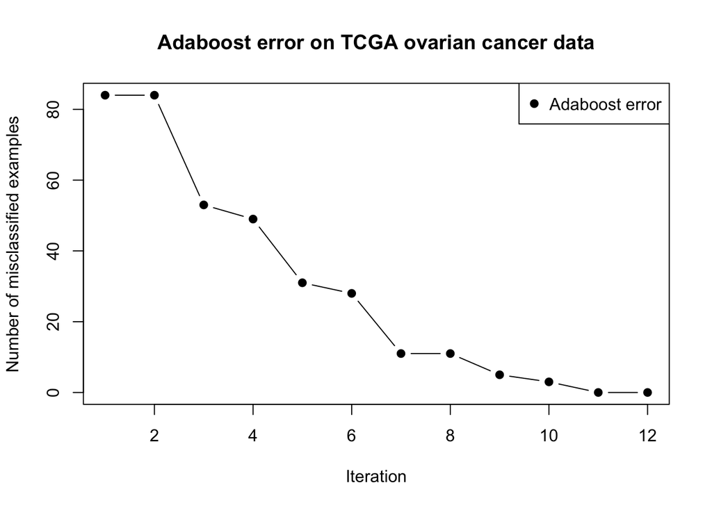

```r
# Get the TCGA ovarian cancer data
library(curatedOvarianData)
data(TCGA_eset)

# Get the clinical data
clin.data = TCGA_eset@phenoData@data
clin.data = na.omit(clin.data[,c('unique_patient_ID', 'summarygrade')])
high.grade.samples = row.names(clin.data[clin.data$summarygrade == 'high',])

# Reformat the expression data (feature matrix)
tcga.expr = data.frame(t(exprs(TCGA_eset)))

# Add the response vector (high-grade, low-grade) to the feature matrix
tcga.expr$Grade = as.factor(ifelse(row.names(tcga.expr) %in% high.grade.samples, 'high', 'low'))

# OPTIONAL: Use lasso for quick feature selection
# (I'm doing this to get a very reduced set of features very quickly)
library(glmnet)
lasso.fit = cv.glmnet(x = as.matrix(tcga.expr[,-ncol(tcga.expr)]),
                      y = tcga.expr$Grade,
                      family = 'binomial',
                      alpha = 1)

# Get the features with non-zero coefficients
coeffs = coef(lasso.fit, s='lambda.min', exact=TRUE)
idx = which(coeffs !=0)
good.features = row.names(coeffs)[idx[2:length(idx)]]

# Perform boosting on the data to classify tumors as 'high-grade' or not
tcga.adaboost = boosting(Grade ~ ., data = tcga.expr[,c(good.features, 'Grade')],
                         boos = T, mfinal = 12)

# Again, plot error by iteration
errors = errorevol(tcga.adaboost, newdata = tcga.expr)$error
plot(errors*nrow(tcga.expr),
     main = 'Adaboost error on TCGA ovarian cancer data',
     xlab = 'Iteration', ylab = 'Number of misclassified examples',
     pch = 19, type = 'b')
legend('topright', legend = 'Adaboost error', col = 'black', pch = 19)
```

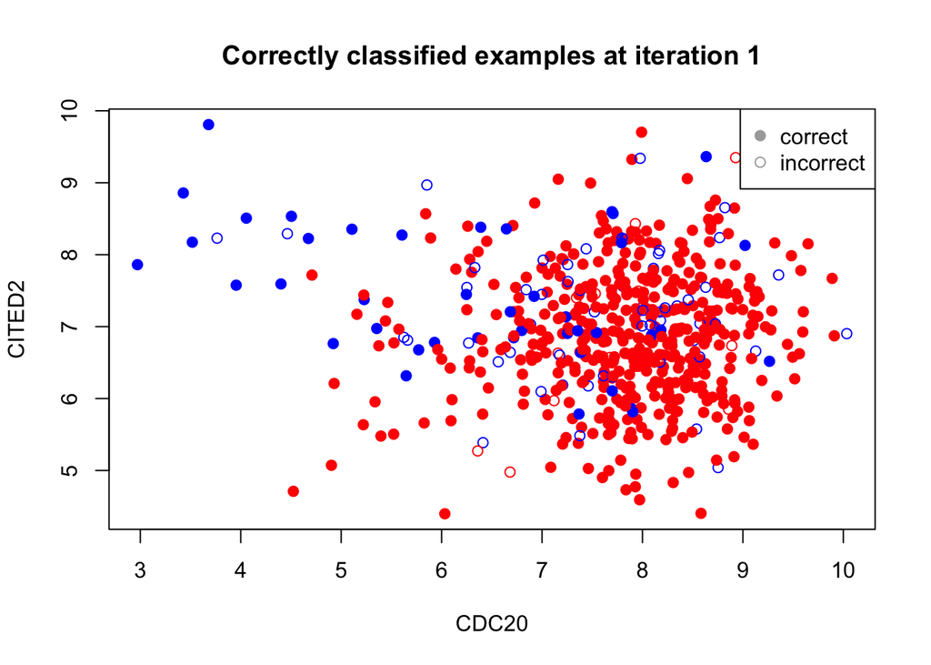

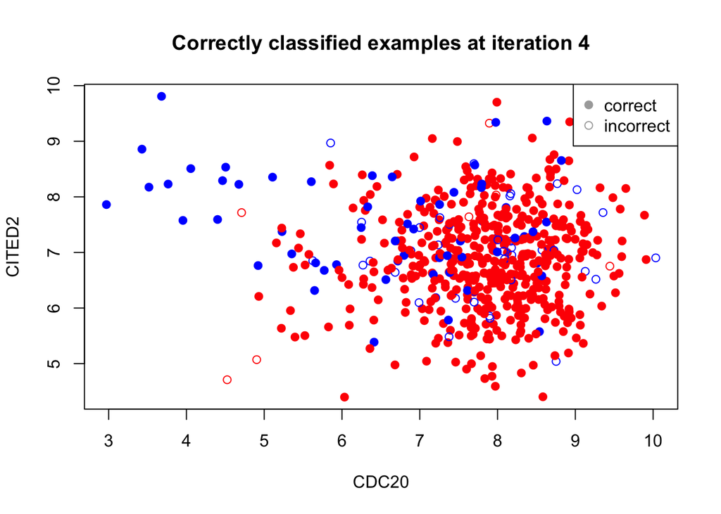

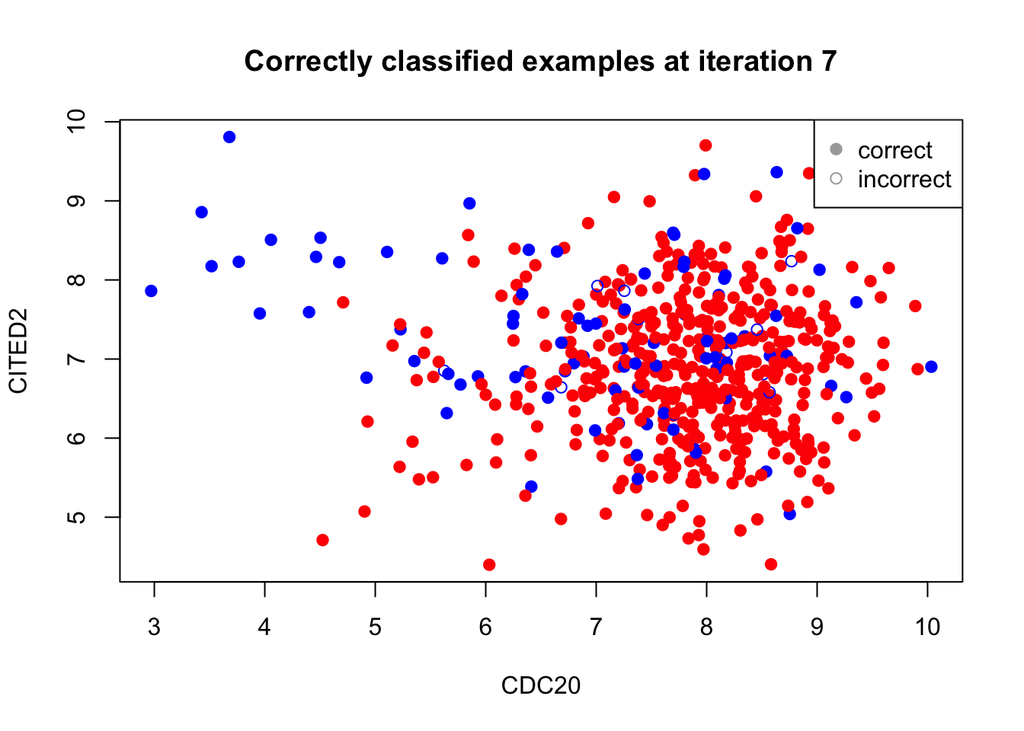

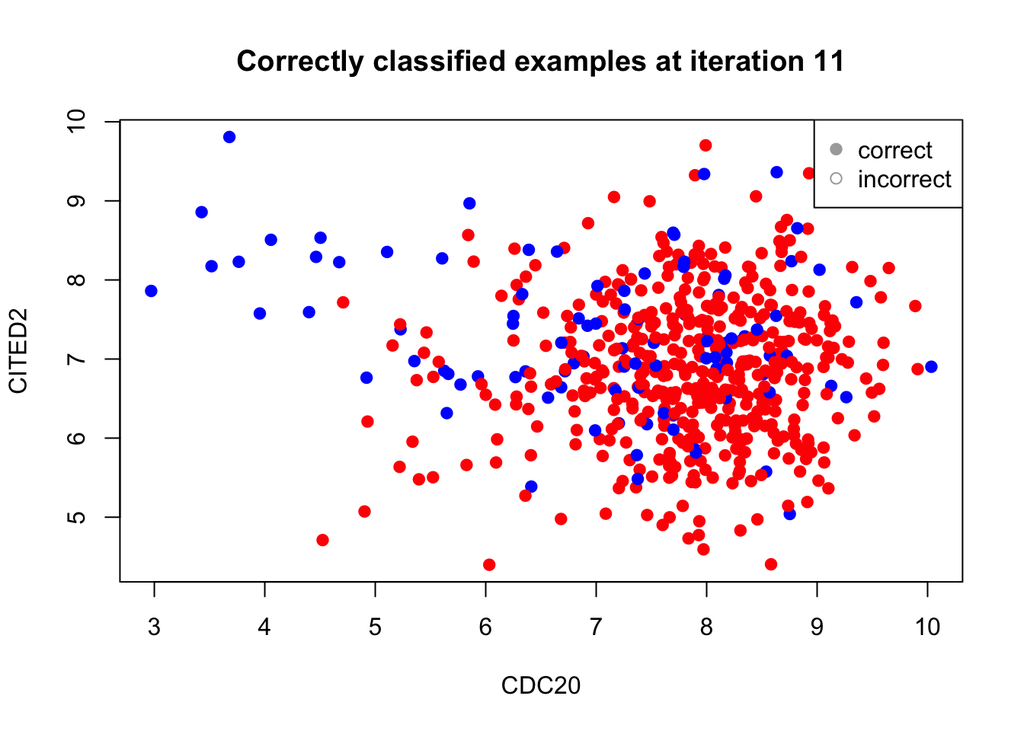

```r
# As above, visualize correct/incorrect examples at different iterations
true.classes = as.character(tcga.expr$Grade)
for (i in c(1,4,7,11)){
     class.assignments = boosting(Grade ~ ., data = tcga.expr[,c(good.features, 'Grade')],
                                  boos = T, mfinal = i)$class
     correct = class.assignments == true.classes
     plot.title = paste0('Correctly classified examples at iteration ', i)
     plot(tcga.expr[,good.features[3:4]],
          col = ifelse(tcga.expr$Grade == 'high', 'red', 'blue'),
          pch = ifelse(correct, 19,1),
          main = plot.title)
     legend('topright', legend = c('correct', 'incorrect'), pch = c(19,1), col = 'darkgray')
}
```

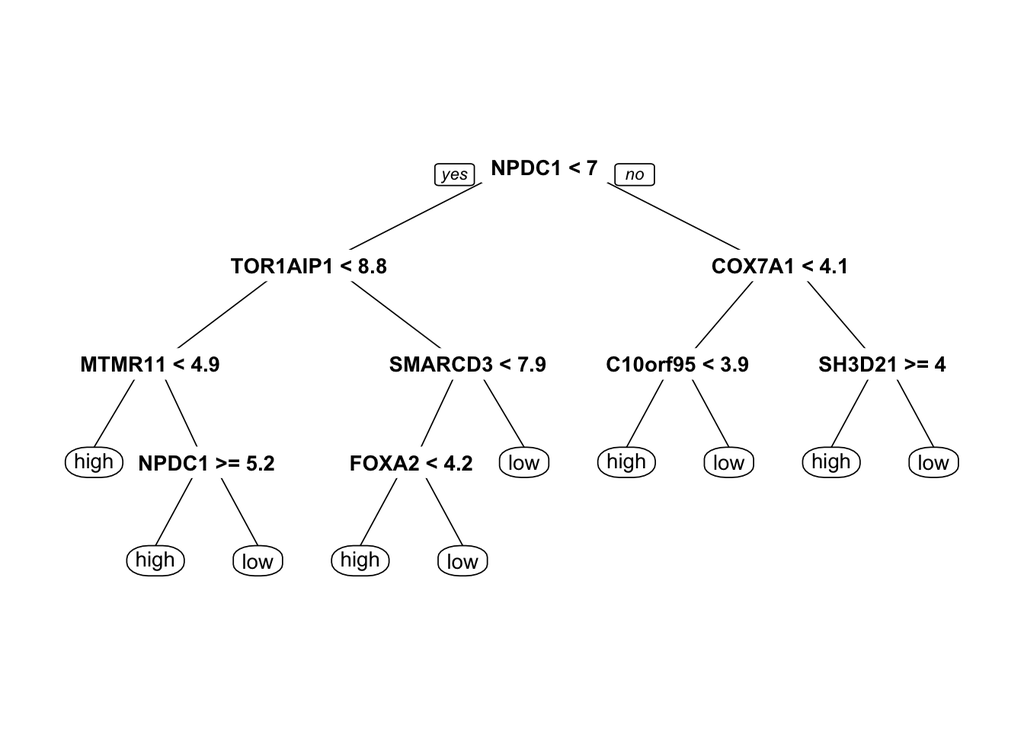

```r
# Visualize one of the trees to see the decision stumps
prp(tcga.adaboost$trees[[1]])
```

### Bagging

##### TCGA ovarian cancer data set

Bagging can be performed in a very similar manner:

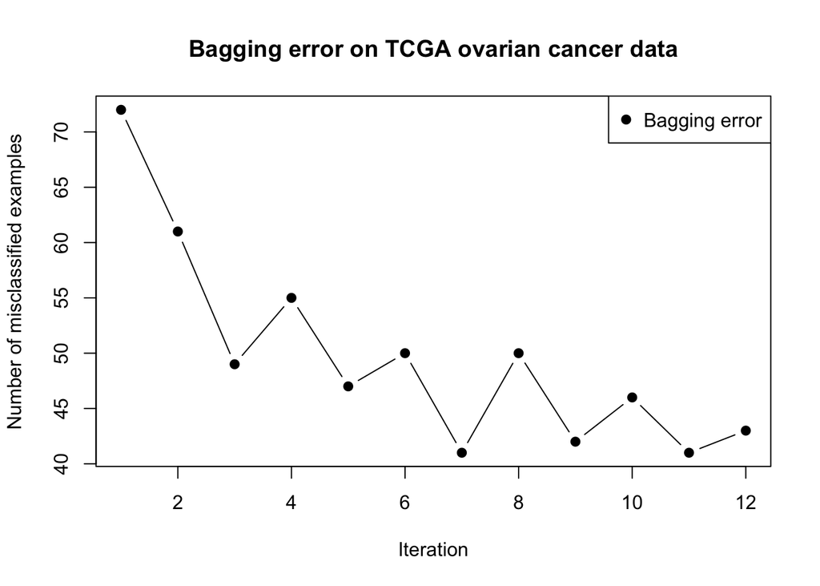

```r
# Bagging TCGA ovarian cancer data
tcga.bagging = bagging(Grade ~ ., data = tcga.expr[,c(good.features, 'Grade')],
                       boos = T, mfinal = 12)

# Plot number of misclassified examples by iteration
errors = errorevol(tcga.bagging, newdata = tcga.expr)$error
plot(errors*nrow(tcga.expr),
     main = 'Bagging error on TCGA ovarian cancer data',
     xlab = 'Iteration', ylab = 'Number of misclassified examples',
     pch = 19, type = 'b')
legend('topright', legend = 'Bagging error', col = 'black', pch = 19)
```

### TODO

Implement the bagging algorithm and apply it to your own data set. You may use the `rpart()` function. *Show and summarize* how the performance acheived by the ensemble compare to the performance of a single classifier.

References: [Adabag paper](https://www.jstatsoft.org/index.php/jss/article/view/v054i02/adabag_An_R_Package_for_Classification_with_Boosting_and_Bagging.pdf), which provides an overview of boosting and bagging algorithms.